# Fordgobike Trip data 2017

## by (Faridah Albalawi)

## Investigation Overview

> Findaing the impact of dayofweek and user type on duration and distance.

## Dataset Overview

> This dataset includes,13 columns and 519700 rows , non of the rows are duplicate ,and there are no missing values. we will analysis the trips data from 2017-06-28 09:47:36.3470, to 2018-01-01 15:12:50.2450.

## 1_ What is Frequency of the day of the week for each user type.

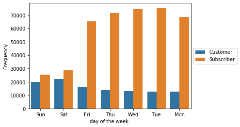

```python
#two qualitative  variables

sb.countplot(data=copy_df, x='start_dayofweek', hue=copy_df['user_type'])
plt.legend(loc='center left', bbox_to_anchor=(1,0.5))
plt.ylabel('Frequency')
plt.xlabel('day of the week ');
```

we can see Customers almost steady frequency in working days but we can notice a little increase in weekends ,and for Subscribers we can see a Significant difference working days and weekends

## 2_ Dose the day of the week and user type have an impact on trip durations .

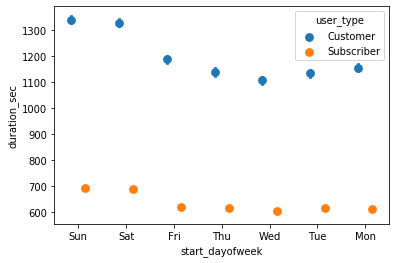

```python
ax = sb.pointplot(data=copy_df.query('duration_sec < 5000'), x = 'start_dayofweek', y = 'duration_sec', hue = 'user_type',
 dodge = 0.3, linestyles = "")
```

For customers Subscribers user we can see increase in duration on weekend ,for subscribers steady pattern on weekdays,Customers tend to ride to longer ditanation

## 3_ What is the relationship between durations and distances for each dayofweek and user type

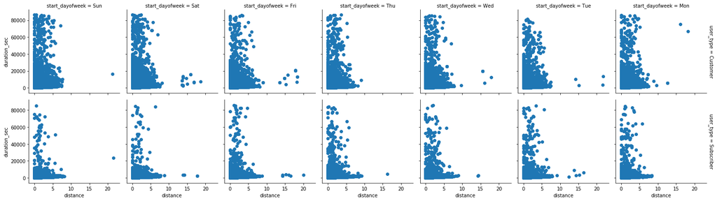

```python
g = sb.FacetGrid(data = copy_df.query('distance < 50'), col = 'start_dayofweek', row = 'user_type', size = 3, margin_titles = True)
g.map(plt.scatter, 'distance', 'duration_sec')
```

there is no relation between duration_sec and distance,Customers tend to ride to longer ditanation ,the subscribers have a steady pattern on all days

### Talk about some of the relationships you observed in this part of the investigation. Were there features that strengthened each other in terms of looking at your feature(s) of interest?

> The customers tend to use the gobike service on weekends, and the subscribers use the service on weekdays the most,but both the customers and subscribers tend to used for long duration on weekends,Customers tend to ride to longer ditanation .

### Were there any interesting or surprising interactions between features?

> that ther isn't relationship between distance and duration